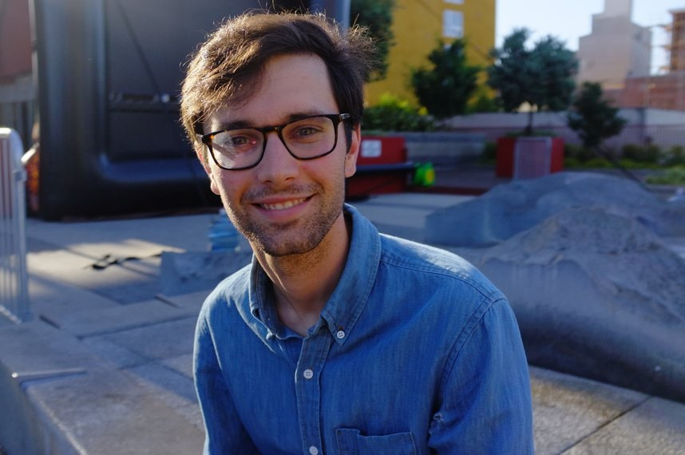

# Kevin Stachelek

## About

I’m a cancer biologist and computational genomicist. My research uses single-cell and bulk sequencing to work out how retinoblastoma tumors arise from developing cone photoreceptors — which cell states are susceptible, and which genomic alterations recur as tumors progress.

I build the analysis tooling that goes with that work: R and Bioconductor packages, Shiny applications, and reproducible Snakemake pipelines for single-cell data.

## Selected publications

### 2025

Shayler DW, **Stachelek K**, Cambier L, Lee S, Bai J, Bhat B, Reid MW, Weisenberger DJ, Aparicio JG, Kim Y, Singh M, Bay M, Thornton ME, Doyle EK, Fouladian Z, Erberich SG, Grubbs BH, Bonaguidi MA, Craft CM, Singh HP, Cobrinik D

[Identification and characterization of early human photoreceptor states and cell-state-specific retinoblastoma-related features](https://doi.org/10.7554/eLife.101918)

eLife

**Stachelek K**, Bhat B, Cobrinik D

[Chevreul: an R bioconductor package for exploratory analysis of full-length single cell sequencing](https://doi.org/10.46471/gigabyte.158)

Gigabyte

### 2022

**Stachelek K**, Harutyunyan N, Lee S, Beck A, Kim J, Xu L, Berry JL, Nagiel A, Reynolds CP, Murphree AL, Lee TC, Aparicio JG, Cobrinik D

[Non‐synonymous, synonymous, and non‐coding nucleotide variants contribute to recurrently altered biological processes during retinoblastoma progression](https://doi.org/10.1002/gcc.23120)

Genes, Chromosomes and Cancer

All publications · Curriculum vitae (PDF)